# Investigating Factors That Lead to Increased Black Maternal Mortality

Author

Elaina Symes

Published

May 3, 2024

## Aim

Maternal mortality in the United States is unusually high compared to other nations with substantial wealth (Crear-Perry et al. 2021). The World Health Organization defines maternal death as the yearly number of deaths from any cause related to or exacerbated by a pregnancy (WHO, n.d.). Death rates are 2-3 times higher for Black birthing people compared to their White counterparts (Wang et al. 2023). This is a social determinant of health (SDOH)- a non-medical factor that influences health outcomes. It is estimated that 3 out of 5 maternal deaths could be prevented by reducing barriers to care, culturally competent medical staff, and more robust protocols and prevention systems for common perinatal or postpartum complications (Chinn et al. 2020). With this project I aim to determine what factors influence increased maternal mortality for Black birthing people.

## Questions

- How does the US compare to other high income countries? Is there a relationship with GDP?
- How do social determinants of health effect health outcomes? Does it vary by race or class?
- What are the common causes of maternal death?

## Scope and System

The bulk of the analysis focuses on maternal mortality and contributing factors in the United States. There is also a brief comparative analysis between other high income countries countries using UNICEF’s maternal mortality data set.

## Methods

Data from UNICEF Data (UNICEF, n.d.) were used to compare the maternal mortality rate (MMR) of the United States and other high income countries and those with robust healthcare systems (Gauld et al. 2014). Each country’s MMR was compared to its average GDP per Capita (World Bank, n.d.).

The Centers for Disease Control and Prevention (CDC) has an ongoing surveillance system that records maternal deaths by age and race which was used to show the trends in death by race (Disease Control and Prevention, n.d.). A National Vital Statistics Report report in 2020 from the CDC was used to find relationships between SDOH and mortality, specifically payment methods for delivery and pre-natal care (Osterman et al. 2021). Additionally, socioeconomic status (SES) and maternal educational attainment data were extracted from a paper investigating how social determinants of health lead to increased maternal mortality (Singh and Lee 2020).

Finally, maternal causes of death were extracted from a paper investigating the trends in maternal mortality from 1969 to 2018 (Singh 2020).

## Results

### Maternal Mortality in the US Compared to High Income Countries

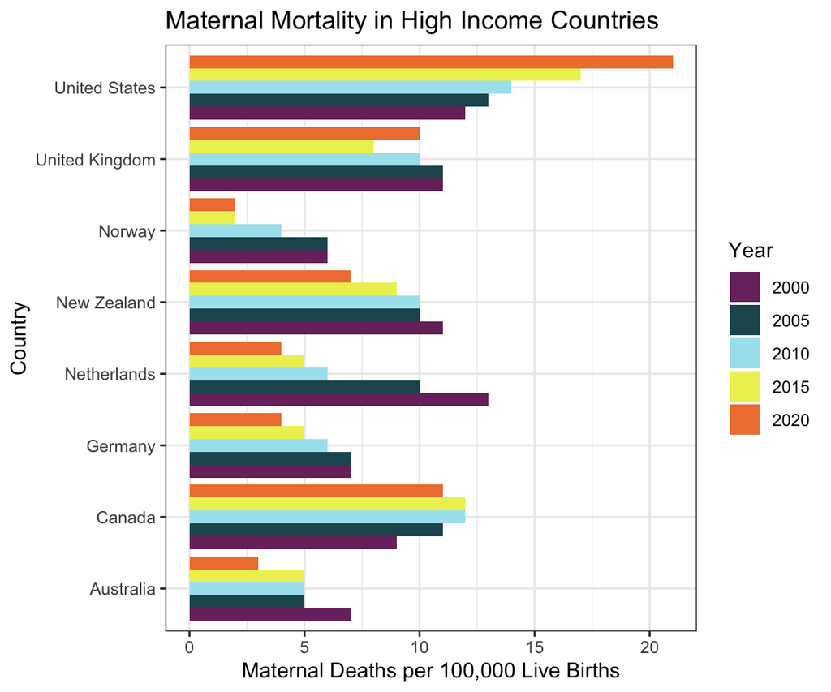

Figure 1: Source: UNICEF

In the majority of the world, maternal mortality has steadily decreased due due to advances in medicine and a global movement towards universal health systems. The United States is an outlier in that it is the only “high income” country not using some form of social insurance. Despite the US spending more healthcare dollars, its health outcomes rank poorly (Gauld et al. 2014). Figure 1 shows that maternal mortality in the US has grown since 2000, unlike its wealthy counterparts. However, 2020 does not match the observed pattern for some countries which could be due to the COVID-19 pandemic.

Countries with Lowest Maternal Mortality Rates

| Country | Average Deaths per 100,000 Live Births |
| --- | --- |
| Iceland | 3.6 |
| Norway | 4.0 |
| Poland | 4.0 |
| Spain | 4.0 |
| Israel | 4.4 |
| Greece | 4.6 |
| Czechia | 4.8 |
| Australia | 5.0 |
| Sweden | 5.0 |
| Austria | 5.8 |
| Germany | 5.8 |

Figure 2: Source: UNICEF

The countries in Figure 2 are those with the smallest average MMR from 2000 to 2020. Population size should be taken into consideration since countries with less people will ultimately have less deaths.

### How Does GDP Effect Maternal Mortality?

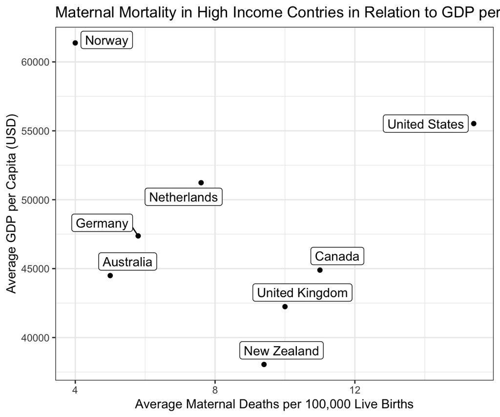

(a) Averages were calculated with data points from 2000, 2005, 2010, 2015, and 2020.

Figure 3: Source: UNICEF, World Bank

Figure 3 further illustrates that the US in an outlier in the relationship between wealth and better outcomes.

### Maternal Mortality in the US by Race

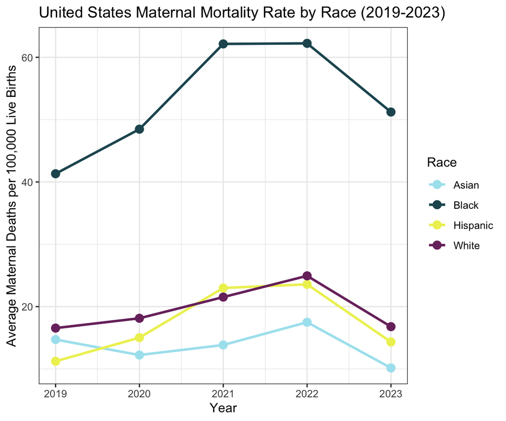

Figure 4: Source: CDC

Black birthing people are significantly more likely to die from complications due to childbirth. This is a complex, nuanced problem that origins dating back to slavery and the Jim Crow. SDOH and access to care play a significant role that will be analyzed further.

### Social Determinants of Health

SDOH are defined as “the conditions in the environments where people are born, live, learn, work, play, worship, and age that affect a wide range of health, functioning, and quality-of-life outcomes and risks” (Health and Human Services, n.d.). The determinants of interest are: onset of pre-natal care, insurance status, education, and SES.

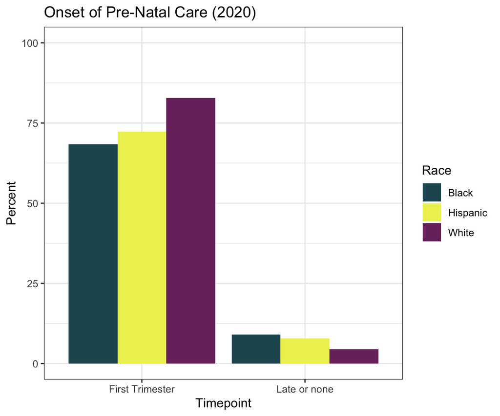

Figure 5: Source: Osterman et al. 2021

Early onset of pre-natal care is strong across all races. Black and Hispanic birthing people are more likely to start pre-natal care late or not at all.

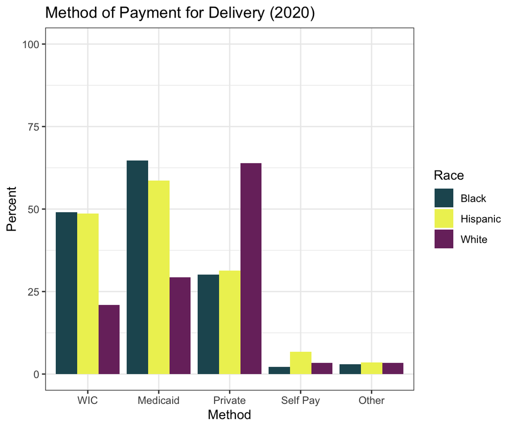

Figure 6: Source: Osterman et al. 2021

There is a stark racial stratification across insurance statuses. Black and Hispanic birthing people are more likely to receive WIC benefits and be on Medicaid. Conversely, White birthing people are more likely to have private insurance.

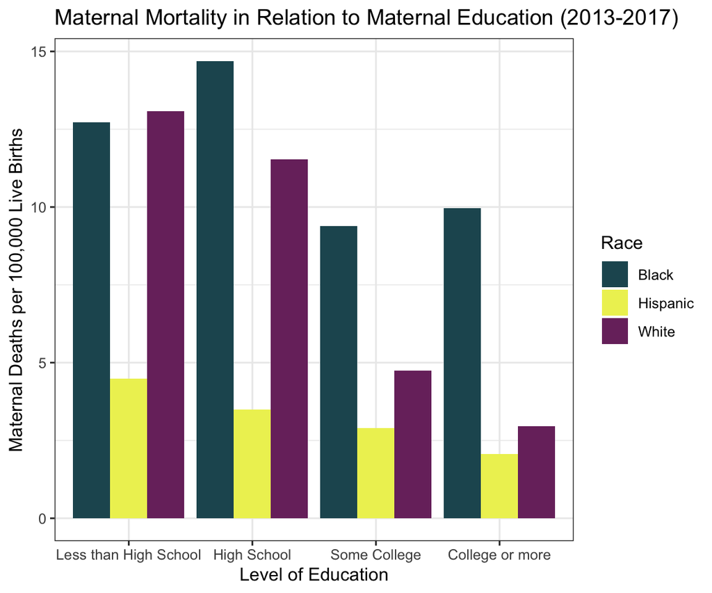

Figure 7: Source: Singh and Lee

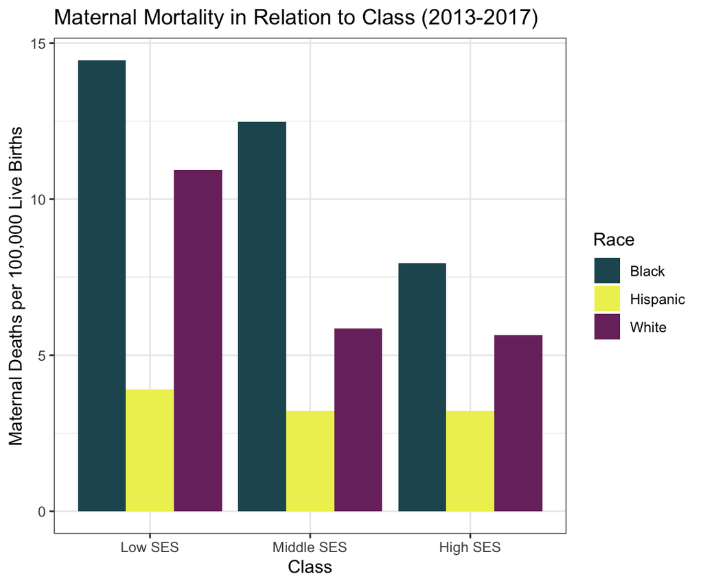

Figure 8: Source: Singh and Lee 2020

### Causes of Death

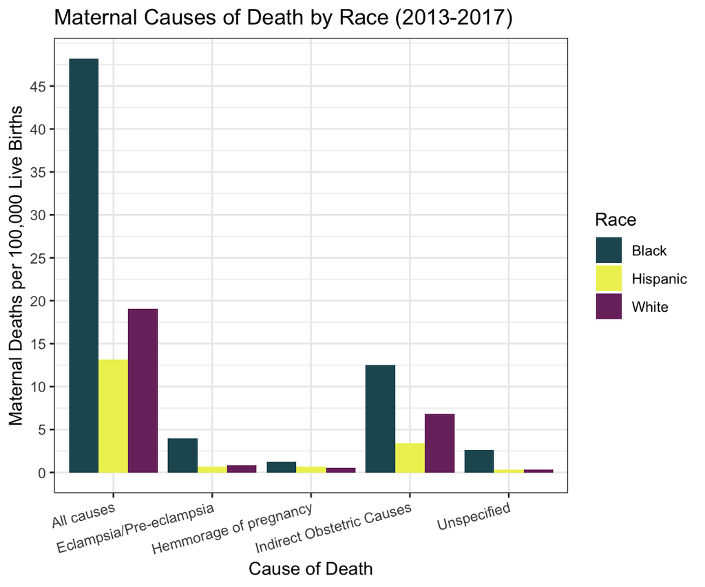

Figure 9: Source: Singh 2020

Indirect obstetric causes are the most common cause of death. These include can include pre-exisiting conditions that are worsened by pregnancy, infections, or sepsis. Black birthing people are at higher risk for eclampsia or pre-eclampsia which is persistent high blood pressure that can lead to other cardiac problems.

## Discussion

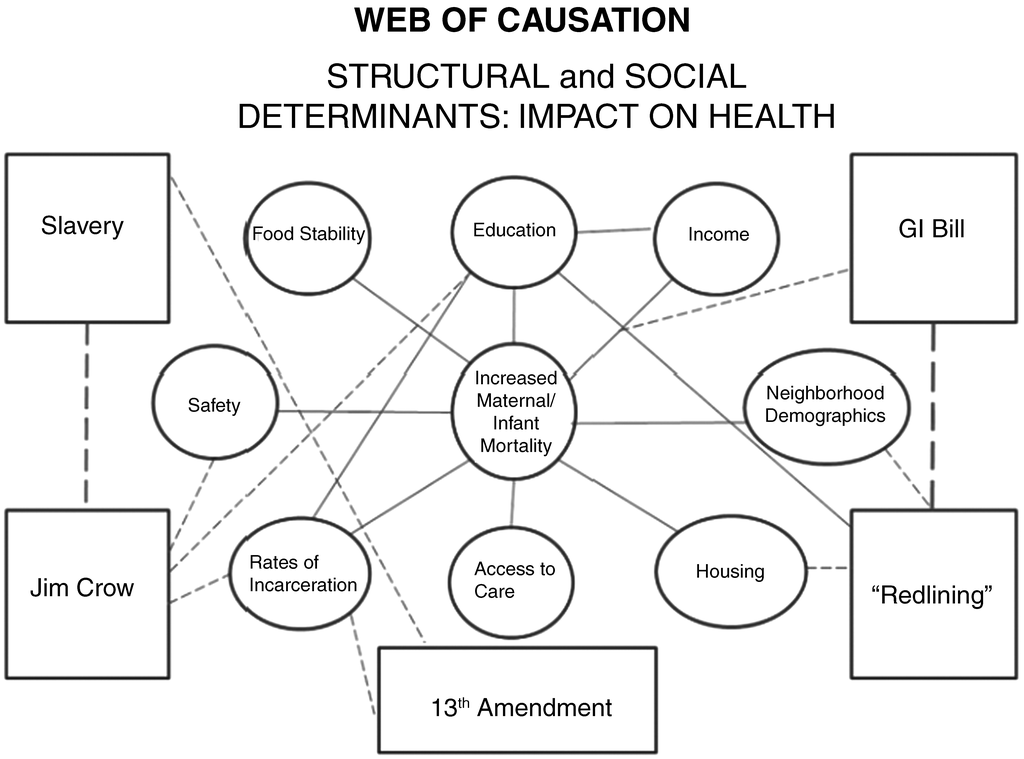

Figure 10: Source: Crear-Perry 2021

Many scholars suggest policy changes such as paid family leave and Medicaid expansion to reduce MMR. Investing in historically disadvantaged communities affected by slavery, Jim Crow, the 13th Amendment, among other policies enforcing systemic racism as seen in Figure 10 will lessen MMR in those communities (Crear-Perry et al. 2021). Although these policies are in the past, they still have modern day consequences. Chinn cites improving provider-patient relationships, healthcare infrastructure, and research as possible avenues for improvement (Chinn et al. 2020). However, structural racism is the primary cause of racial health disparities so interventions should address more than the healthcare system like housing, safety, income, etc.

Many providers (MDs, nurses, etc.) still hold onto racial biases and medical myths. There are still healthcare professionals who believe that Black people cannot feel pain and therefore, receive lower quality treatment (Crear-Perry et al. 2021). Increasing the number of Black physicians, particularly OB/GYNs, will help improve provider relationships and trust.

Future research should investigate other SDOH besides those health related to provide well-rounded, whole solutions. Also, having a more thorough understanding of the indirect obstetric causes and eclampsia/pre-eclampsia will significantly impact MMR as seen in Figure 9.

In sum, Black maternal mortality is preventable and more research and protective policies are needed to dismantle systemic racism to increase health equity.

## References

Chinn, Juanita J., Esther Eisenberg, Shavon Artis Dickerson, Rosalind B. King, Nahida Chakhtoura, Issel Anne L. Lim, Katherine L. Grantz, Charisee Lamar, and Diana W. Bianchi. 2020. “Maternal Mortality in the United States: Research Gaps, Opportunities, and Priorities.” *American Journal of Obstetrics and Gynecology* 223 (4): 486–492.e6. https://doi.org/10.1016/j.ajog.2020.07.021.

Crear-Perry, Joia, Rosaly Correa-de-Araujo, Tamara Lewis Johnson, Monica R. McLemore, Elizabeth Neilson, and Maeve Wallace. 2021. “Social and Structural Determinants of Health Inequities in Maternal Health.” *Journal of Women’s Health* 30 (2): 230–35. https://doi.org/10.1089/jwh.2020.8882.

Disease Control, Centers for, and Prevention. n.d. “VSRR Provisional Maternal Death Counts and Rates.”

Gauld, Robin, Jako Burgers, Mark Dobrow, Rubin Minhas, Claus Wendt, Alan B. Cohen, and Karen Luxford. 2014. “Healthcare System Performance Improvement.” *Journal of Health Organization and Management* 28 (1): 2–20. https://doi.org/10.1108/jhom-03-2013-0057.

Health, U. S. Department of, and Human Services. n.d. “Social Determinants of Health.” https://health.gov/healthypeople/priority-areas/social-determinants-health.

Osterman, Michelle, Brady Hamilton, Joyce Martin, Anne Driscoll, and Claudia Valenzuela. 2021. “Births: Final Data for 2020.” https://doi.org/10.15620/cdc:112078.

Singh, Gopal K. 2020. “Trends and Social Inequalities in Maternal Mortality in the United States, 1969-2018.” *International Journal of Maternal and Child Health and AIDS (IJMA)* 10 (1): 29–42. https://doi.org/10.21106/ijma.444.

Singh, Gopal K., and Hyunjung Lee. 2020. “Trends and Racial/Ethnic, Socioeconomic, and Geographic Disparities in Maternal Mortality from Indirect Obstetric Causes in the United States, 1999-2017.” *International Journal of Maternal and Child Health and AIDS (IJMA)* 10 (1): 43–54. https://doi.org/10.21106/ijma.448.

UNICEF. n.d. “UNICEF Maternal Mortality.” https://data.unicef.org/topic/maternal-health/maternal-mortality/.

Wang, Siwen, Kathryn M. Rexrode, Andrea A. Florio, Janet W. Rich-Edwards, and Jorge E. Chavarro. 2023. “Maternal Mortality in the United States: Trends and Opportunities for Prevention.” *Annual Review of Medicine* 74 (1): 199–216. https://doi.org/10.1146/annurev-med-042921-123851.

WHO. n.d. “Maternal Deaths.” https://www.who.int/data/gho/indicator-metadata-registry/imr-details/4622.

World Bank. n.d. “GDP Per Capita World Bank.”